# Gender Differences in Heart Disease Symptoms

Farrah Johnson and Mariam Ikram

2026-04-06

# Intro

Heart disease is the leading cause of death in the United States, making it essential to understand how its risk factors and symptoms appear across different populations. This issue is especially important for women, who have historically been underrepresented in medical research and often present with atypical or non‑classic symptoms. As a result, women are more likely to be misdiagnosed or diagnosed later than men, contributing to preventable complications and poorer outcomes; raising the question of whether commonly used datasets reflect the same disparities observed in real clinical settings.

This analysis addresses two central questions:

1. What does heart disease look like in the general population represented in this dataset?
2. Do symptom patterns differ between men and women, and between individuals with and without heart disease?

By answering these questions, we can evaluate whether the dataset mirrors known clinical trends or whether it introduces biases that may influence predictive modeling or interpretation.

To address these question we use the “Heart Failure Prediction Dataset” from Kaggle, compiled by FEDESORIANO in 2021. This dataset merges five different clinical studies conducted in Hungary, Switzerland, and the United States, joined by 11 demographic, clinical, and exercise related variables, resulting in 918 observations. Because the dataset merges multiple sources, the variables may reflect differences in measurement or population characteristics, making exploratory analysis especially important.

Our approach uses exploratory data analysis techniques to compare how heart‑disease‑related symptoms and indicators appear in men versus women. We begin by using boxplots to identify potential outliers in numeric variables such as age, resting blood pressure, maximum heart rate, and oldpeak. Categorical variables—including chest pain type, resting ECG, and ST slope are evaluated using bar charts and proportion plots to examine distribution patterns across sex and disease status. We then use faceted visualizations to directly compare men and women within the heart‑disease population.

This strategy allows us to determine whether the dataset mirrors known clinical trends, such as women presenting different ECG patterns, showing different chest‑pain distributions, or being underrepresented in diagnostic categories. Ultimately, this analysis helps the reader understand both how heart disease manifests in this dataset and whether these patterns align with real‑world disparities that affect women’s cardiovascular health.

Source: fedesoriano. (September 2021). Heart Failure Prediction Dataset. Retrieved [April 2026] from https://www.kaggle.com/fedesoriano/heart-failure-prediction.

# Packages

- tidyverse: data wrangling (dplyr), plotting (ggplot2), and general data manipulation (forcats)
- janitor: cleans columns names and simple tabulations
- knitr : Create nice tables in the report
- kableExtra: Enhancing table appearance (border, alignment, etc.)

A glimpse at the raw heart dataset

```
## Rows: 918
## Columns: 12
## $ Age            <int> 40, 49, 37, 48, 54, 39, 45, 54, 37, 48, 37, 58, 39, 49,…
## $ Sex            <chr> "M", "F", "M", "F", "M", "M", "F", "M", "M", "F", "F", …
## $ ChestPainType  <chr> "ATA", "NAP", "ATA", "ASY", "NAP", "NAP", "ATA", "ATA",…
## $ RestingBP      <int> 140, 160, 130, 138, 150, 120, 130, 110, 140, 120, 130, …
## $ Cholesterol    <int> 289, 180, 283, 214, 195, 339, 237, 208, 207, 284, 211, …
## $ FastingBS      <int> 0, 0, 0, 0, 0, 0, 0, 0, 0, 0, 0, 0, 0, 0, 0, 0, 0, 0, 0…
## $ RestingECG     <chr> "Normal", "Normal", "ST", "Normal", "Normal", "Normal",…
## $ MaxHR          <int> 172, 156, 98, 108, 122, 170, 170, 142, 130, 120, 142, 9…
## $ ExerciseAngina <chr> "N", "N", "N", "Y", "N", "N", "N", "N", "Y", "N", "N", …
## $ Oldpeak        <dbl> 0.0, 1.0, 0.0, 1.5, 0.0, 0.0, 0.0, 0.0, 1.5, 0.0, 0.0, …
## $ ST_Slope       <chr> "Up", "Flat", "Up", "Flat", "Up", "Up", "Up", "Up", "Fl…
## $ HeartDisease   <int> 0, 1, 0, 1, 0, 0, 0, 0, 1, 0, 0, 1, 0, 1, 0, 0, 1, 0, 1…
```

# Data Preperation

Before beginning the analysis, we cleaned the dataset by standardizing variable names, converting categorical variables, and checking for missing values. The cleaning code was executed but suppressed in the final report to maintain readability.

Sample of Cleaned Heart Dataset

| age | sex | chest_pain_type | resting_bp | cholesterol | fasting_bs | resting_ecg | max_hr | exercise_angina | oldpeak | st_slope | heart_disease |
| --- | --- | --- | --- | --- | --- | --- | --- | --- | --- | --- | --- |
| 40 | Male | Atypical Angina | 140 | 289 | No | Normal | 172 | No | 0.0 | Up | No |
| 49 | Female | Non-Anginal Pain | 160 | 180 | No | Normal | 156 | No | 1.0 | Flat | Yes |
| 37 | Male | Atypical Angina | 130 | 283 | No | ST-T Abnormality | 98 | No | 0.0 | Up | No |
| 48 | Female | Asymptomatic | 138 | 214 | No | Normal | 108 | Yes | 1.5 | Flat | Yes |
| 54 | Male | Non-Anginal Pain | 150 | 195 | No | Normal | 122 | No | 0.0 | Up | No |
| 39 | Male | Non-Anginal Pain | 120 | 339 | No | Normal | 170 | No | 0.0 | Up | No |
| 45 | Female | Atypical Angina | 130 | 237 | No | Normal | 170 | No | 0.0 | Up | No |
| 54 | Male | Atypical Angina | 110 | 208 | No | Normal | 142 | No | 0.0 | Up | No |
| 37 | Male | Asymptomatic | 140 | 207 | No | Normal | 130 | Yes | 1.5 | Flat | Yes |
| 48 | Female | Atypical Angina | 120 | 284 | No | Normal | 120 | No | 0.0 | Up | No |

The table below provides a variable dictionary summarizing each variable in the dataset, including its definition and measurement type. Along with a background on the explored variables within the analysis to help the reader understand the structure of the dataset and the role each variable plays in the overall analysis.

Variable Dictionary for Heart Dataset

| variable | description |
| --- | --- |
| age | Age of patients in years |
| sex | Biological sex (Male/Female) |
| chest_pain_type | Type of chest pain experienced (Typical Angina, Atypical Angina, Non-Anginal Pain, Asymptomatic) |
| resting_bp | Resting blood pressure (mm Hg) |
| cholesterol | Serum cholestrol level (mg/dL) |
| fasting_bs | Fasting blood sugar > 120 mg/dl (Yes/No) |
| resting_ecg | Resting electrocardiogram results (Normal, ST-T Abnormality, LV Hypertrophy) |
| max_hr | Maximum heart rate achieved during exercise |
| exercise_angina | Excercise-induced angina (Yes/No) |
| oldpeak | ST depression induced by exercise relative to rest |
| st_slope | Slope of the peak ST segment |
| heart_disease | Presence of heart disease (Yes/No) |

## Clinical Background for Key Heart Variables

Several variables in this dataset come from electrocardiograms (ECG) test that records the electrical signals of the heart and exercise stress tests. These exercises help determine how the heart responds to physical activity and whether blood flow to the heart is reduced.

- Ischemia: lack of blood flow and consequentially oxygen to a body part; in this case the heart (myocardial ischemia)
- Angina: clinical term for chest pain caused by ischemia
- ST in this dataset refers to the ST segment of the ECG waveform, specifically the portion between the S point and the T point. This segment is clinically important because changes in its level or slope can indicate ischemia
- Oldpeak: This measures how much the ST segment drops during the exercise compared to rest. Higher values often indicative of ischemia
- ST Slope: This describes the direction of the ST segment during peak exercise
  - Upsloping: generally indicative of a healthy heart
  - Flat: related to ischemia, indicative of heart disease
  - Downsloping: related to ischemia, indicative of heart disease
- Exercise Angina: Indicates whether the patient experienced chest pain during exercise, which can be a sign of reduced oxygen supply to the heart
  - Typical Angina: chest pain caused by ischemia; triggered by exertion, relieved by rest
  - Atypical Angina: chest pain that has some, but not all features of typical angina
  - Non-Anginal Pain: chest pain that has one or none of the features of typical angina.
  - Asymptomatic: no pain felt but heart issues may be present
- Resting ECG: electrical activity of your heart while relaxed
  - Normal: electrical signal and muscle thickness seem normal
  - ST-T Wave Abnormality: shifts in ST segment that may suggest ischemia or an electrolyte imbalance; may be an indicator of heart disease
  - Left Ventricular Hypertrophy (LVH): “tall” waves in ECG indicating large, thick muscle mass of heart chamber due to long standing conditions like high blood pressure; strong indicator of heart disease

## Check for Outliers

To identify potential outliers, we created boxplots to evaluate the main numeric variables associated with heart disease in this dataset, including age, maximum heart rate, oldpeak, and resting blood pressure. Categorical variables such as chest pain type, resting ECG, and ST slope were excluded because they cannot have statistical outliers; instead, their distributions are examined later in the EDA section.

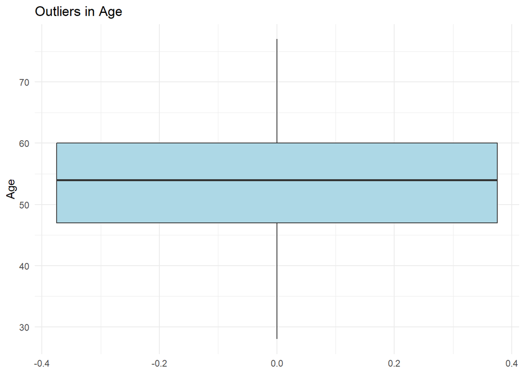

Age does not show any extreme outliers, meaning all the patients fall around a consistent age range.

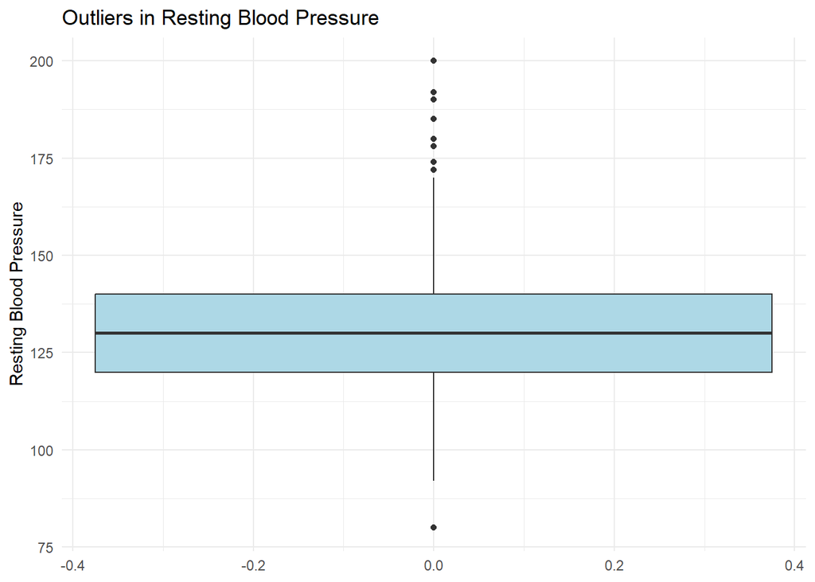

Resting blood pressure shows several outliers above 150, and one unusually low value below a 100. A subset of patient differ significantly from the rest in their resting blood pressure reading.

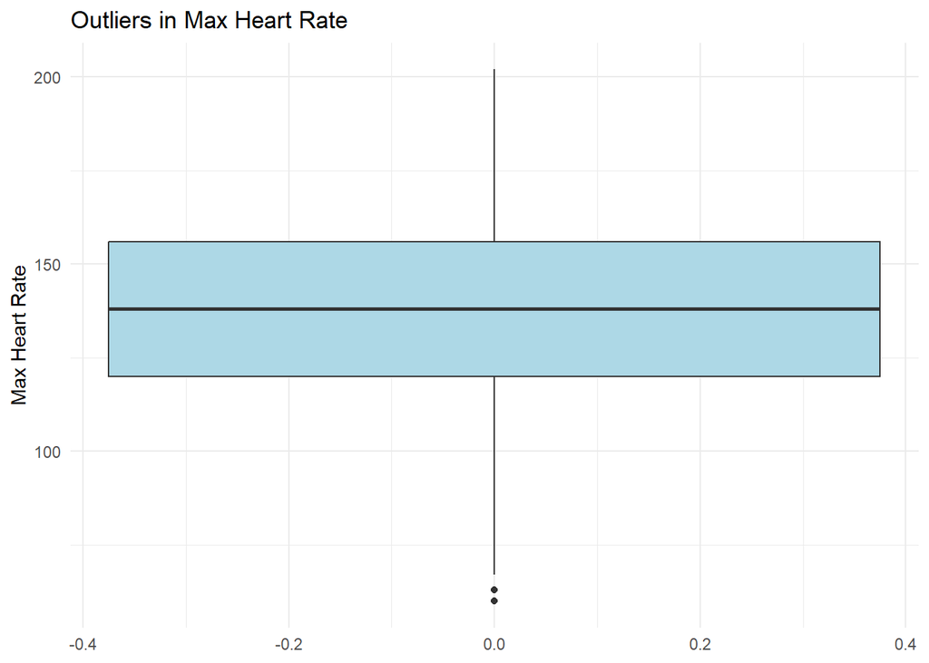

Max heart heart does have some extreme outliers in the lower end of the spectrum with heart rates below a 100, showing a small subset of patients had significantly reduced exercise capacity in comparison to the rest of the sample.

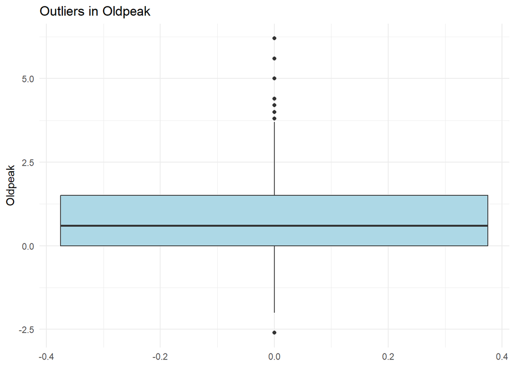

Oldpeak showed several extreme outliers above 2.5 and one unusually low value below -2.5. This indicates that a subset of patients experienced significantly greater and unusually negative ST segment depression during exercise.

While we identified several outliers across the variables we will be using to analyze this dataset, we chose not to remove them. In many analyses outliers are removed to ensure the most accurate representation of the data. However, in this case, the outliers represent real patients with clinically significant conditions, removing them would eliminate important clinical variations leading to possibly incorrect and inaccurate representation and understanding of the population. Keeping them in ensures the analysis reflects the full range of the patients present with their unique variations.

# Data Analysis

We will now explore our dataset through visualizations and summary statistics.

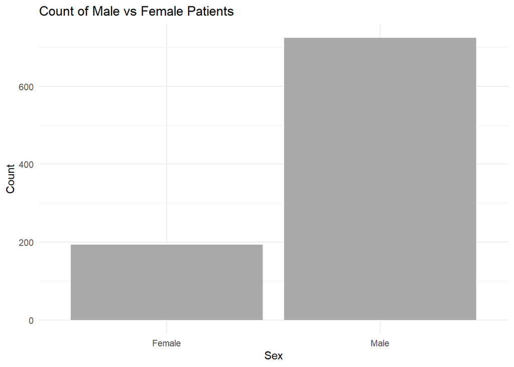

The bar chart shows the count of male vs female patients. This dataset contains significantly more males than females patients, creating a clear imbalance in the sample. This imbalance is important showing that raw counts alone can be misleading when comparing groups. It also hints at sampling bias or oversampling of male patients, which is common in meany heart data sets. Because of this imbalance proportion based visualizations are necessary later in the analysis to make fair comparisons between both genders.

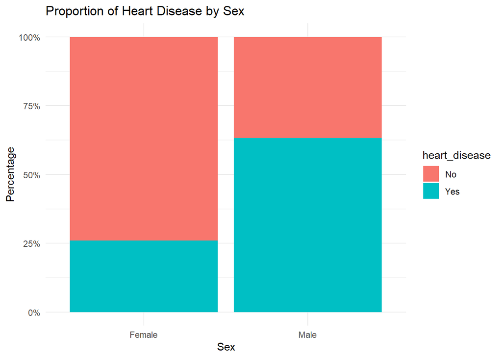

This proportion bar chart shows the prevalence of heart disease in males vs females. We used a proportion chart due to the raw count imbalance.

The proportion chart shows that about 63% of males have heart disease in comparison to only 26% of females that do. This correlates with real world known heart disease patterns, which indicates men are more likely to have heart disease than women.

## Disease vs. No Disease

What symptoms are typically associated with heart disease? What symptoms distinguish heart disease from no heart disease?

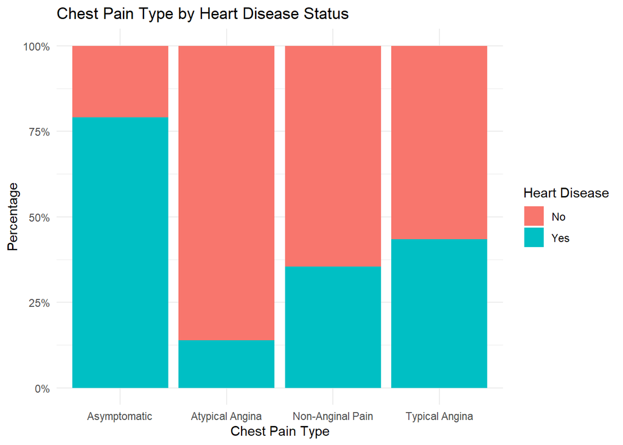

This chart shows chest pain types between within each heart disease group. Among individual’s with heart disease asymptomatic chest pain type is most prevalent, followed by typical angina, non-anginal pain, and atypical angina. This highlights that many patients with heart disease do not experience typical chest pain symptoms, marking it as a meaningful symptom to explore by gender.

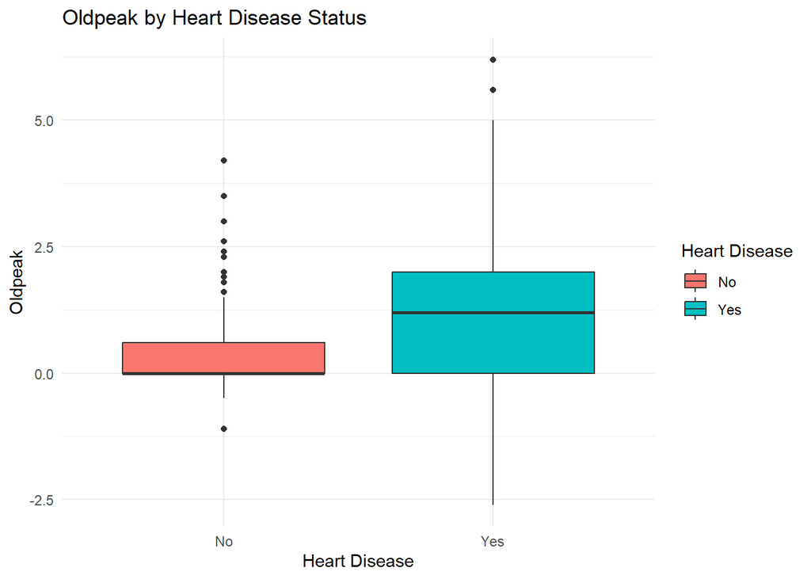

Individuals with heart disease tend to have a higher oldpeak in comparison to people with no heart disease, reflective of typical symptoms due to more pronounced ST‑segment depression during exercise. This pattern aligns with typical symptoms of ischemia and reinforces oldpeak as an important variable for distinguishing between the two groups.

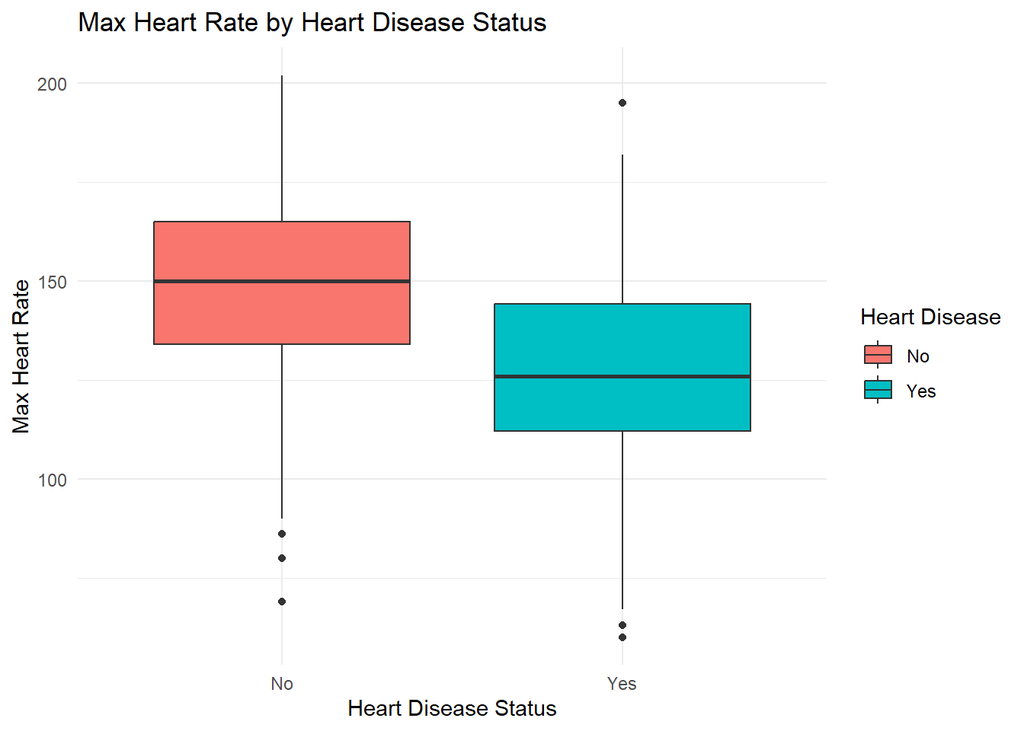

Individuals with heart disease tend to have lower maximum heart rates than those without the condition, as shown by the distribution of the box plot, is in alignment with reduced cardiac functions. We can conclude that lower heart rates is a significant indicator of heart disease.

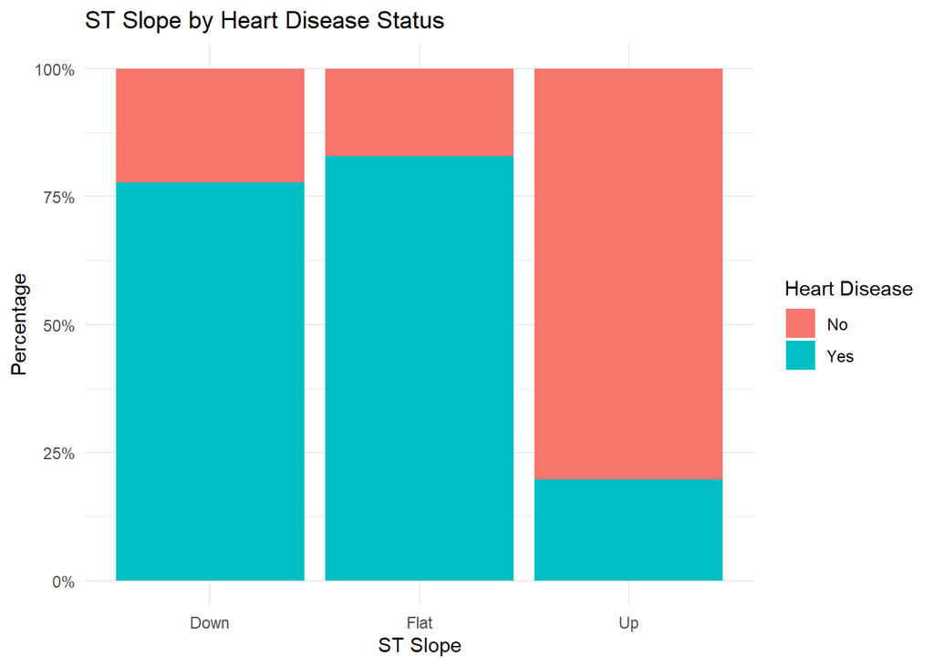

A down and flat ST slope is associated with patients with heart disease, this chart showcases patients with heart disease are prone to a down or flat ST slope with minimal variance, reinforcing its diagnostic relevance.

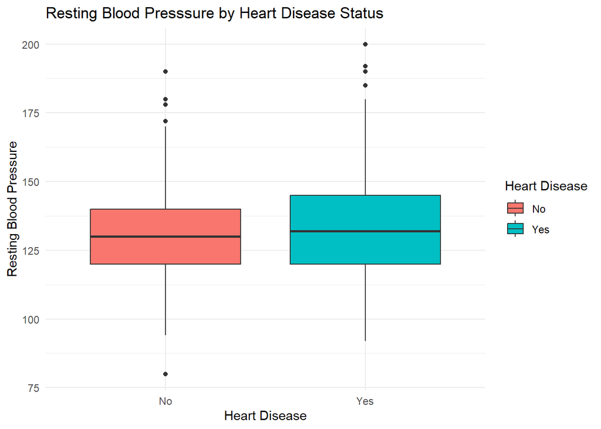

Individuals with heart disease tend to have slightly higher resting blood pressure, as shown in the boxplot. While the difference is not dramatic, the heart‑disease group shows greater spread in the upper range of the distribution, indicating a higher resting blood pressure is more commonly found in heart disease. This suggests that resting blood pressure, alongside other clinical variables, may be a useful indicator when distinguishing individuals with and without heart disease.

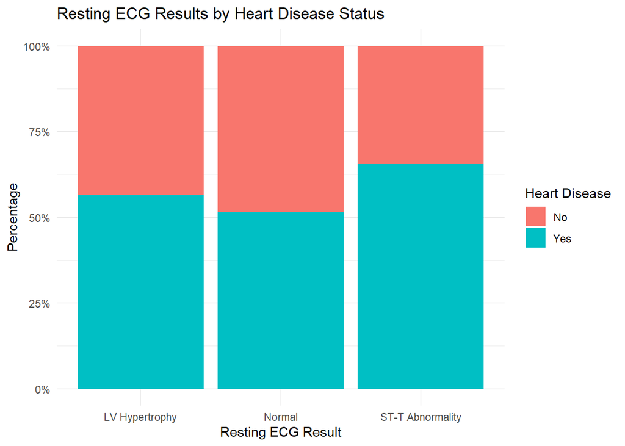

Among people with heart disease, ST–T abnormalities are the most common resting ECG finding, followed by left ventricular hypertrophy (LVH) and then normal ECG results. This indicates that many patients with heart disease show electrical evidence of ischemia or structural changes at rest. In contrast, individuals without heart disease show a higher proportion of normal ECGs, marking it as a clinically relevant marker of heart disease.

## Male vs Female (Disease vs No Disease)

Do these symptoms differ between men and women, accounting for disease vs. no disease.

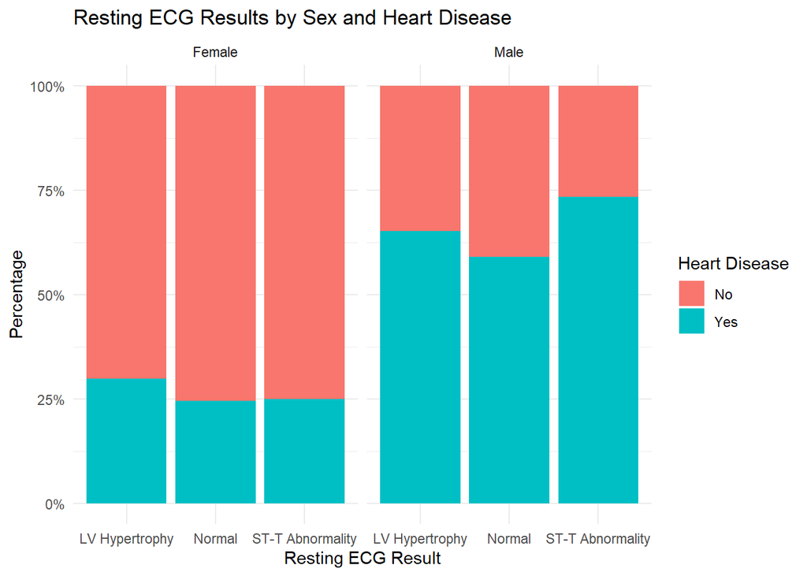

Women and men present vastly different resting ECG pattern across disease groups. In women, the no‑disease group makes up the majority of the bar across all Resting ECG categories (ST–T abnormality, LV hypertrophy, and normal). The disease group is very small, so its portion of each bar is minimal. This means that even though women show ECG changes, these changes occur mostly in women without heart disease, reinforcing that Resting ECG abnormalities are not strong indicators of heart disease in women, reflecting clinical studies showing women tend to present with subtler or “nonspecific” ECG changes, making heart disease harder.

In contrast, men show the expected clinical pattern: the disease group dominates, especially in ST–T abnormalities, followed by LV hypertrophy and then normal results- a pattern more consistent with typical heart disease presentation.

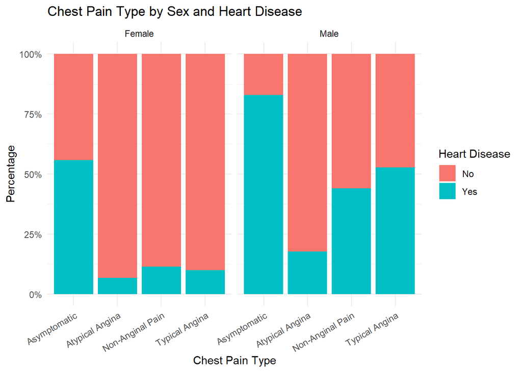

Asymptomatic is the most common chest pain type in the heart disease population, in both women and men. However, the patterns for the remaining chest pain types differ greatly by sex.

In women, the other chest pain categories’ (atypical angina, non‑anginal pain, and typical angina) distribution is relatively flat, showing little variation across chest pain types. Each make up less than 15% of cases, with atypical angina being the least common. This aligns with clinical evidence showing that women often present with non‑classic chest pain, which contributes to under‑recognition of heart disease in female patients

In men, the pattern is more distinct: after asymptomatic pain, typical angina is the next most common, followed by non‑anginal pain, with atypical angina being the least frequent, creating a clear gradient of chest pain types across the males with heart disease population, representing typically associated heart disease ischemic patterns and symptoms.

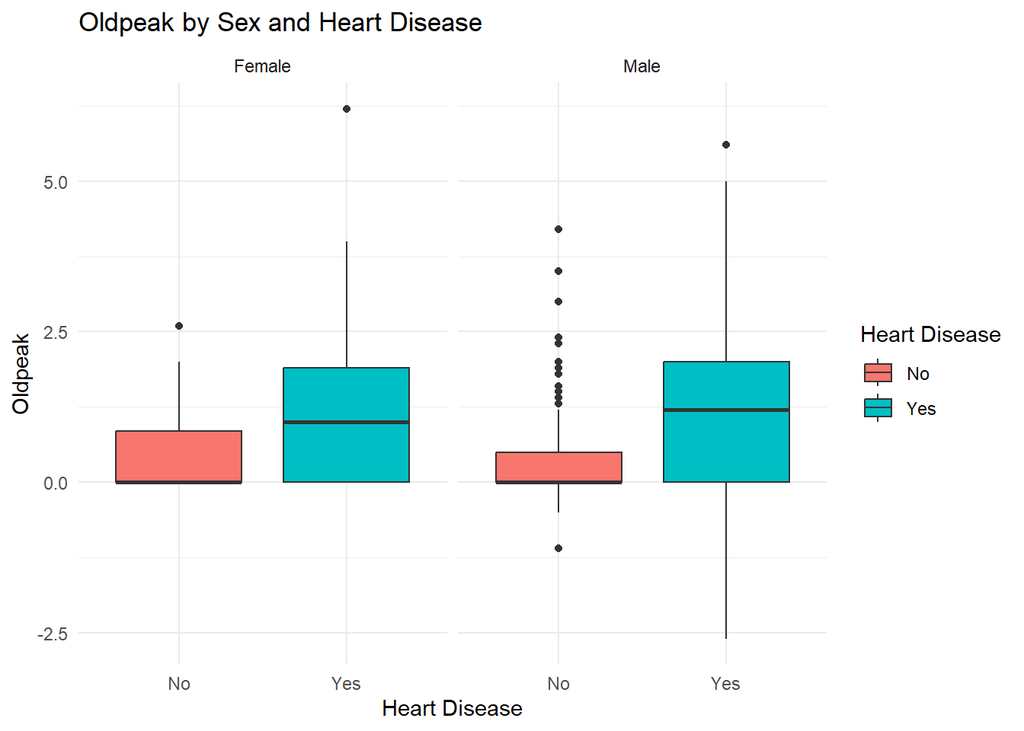

Women with no heart disease have a higher oldpeak than men with no heart disease, showing a greater ST segment depression during exercise in the non-disease group. However in the heart diseased population, women and men both have a similar old peak distribution. This aligns with clinical trials showing that old peak is generally an unreliable indicator of heart disease in women than in men.

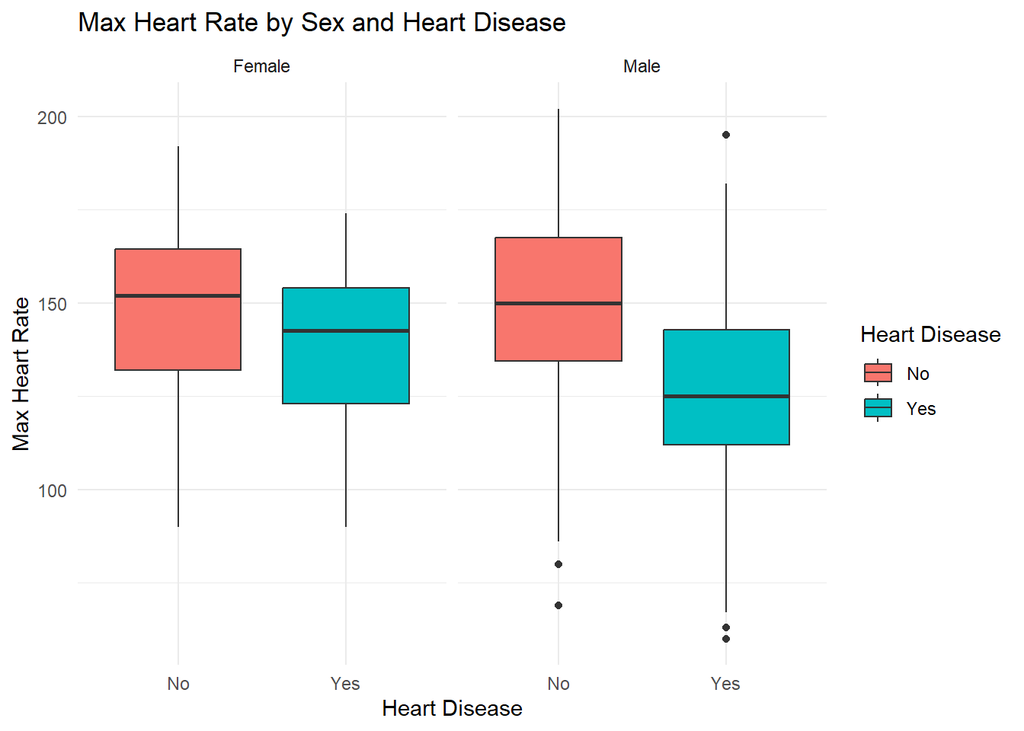

Max heart rate between men and women across the non-disease population is fairly similar.

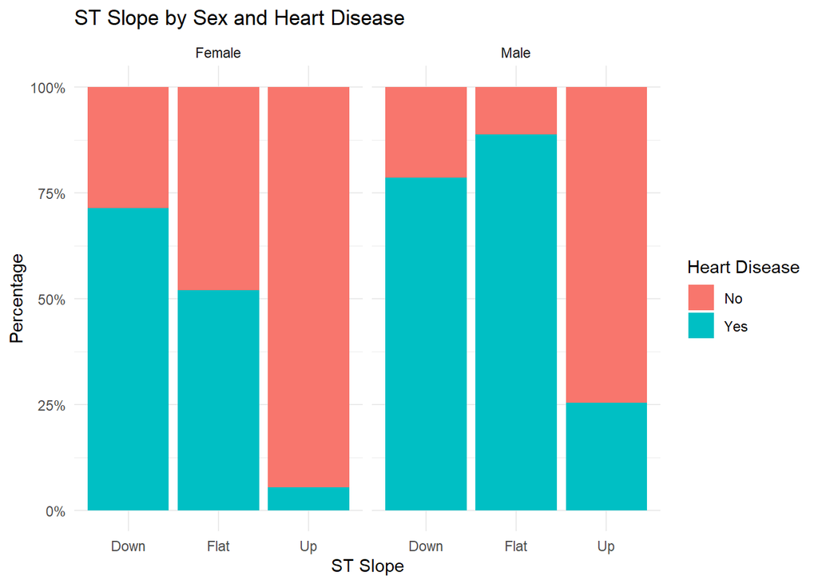

In this dataset, men with heart disease most often show a flat ST slope, followed by down, with up being least common. Women show the opposite pattern; downsloping is most common, then flat, and upsloping is rare.

Clinically, ST slope is known to be a stronger predictor of heart disease in women than oldpeak. This is reflective in the chart- over 15% of men with heart disease still show an upward slope (a pattern usually seen in healthier hearts), while fewer than 10% of women do, reinforcing the diagnostic importance of ST slope in identifying heart disease in women.

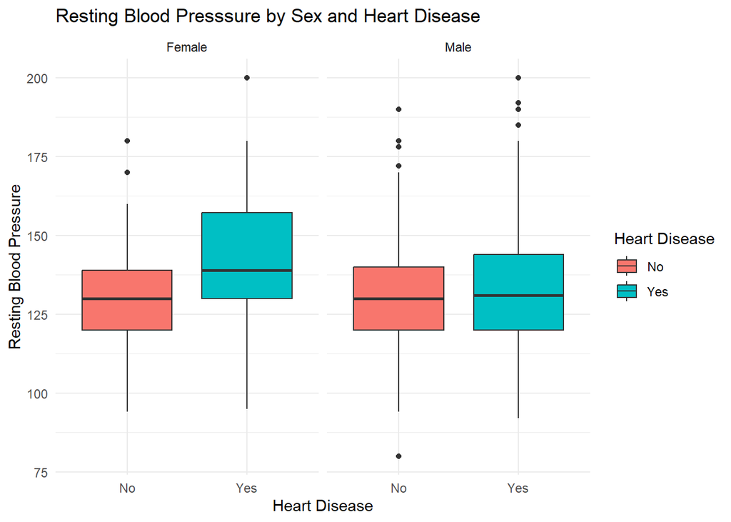

Women and men show similar resting blood pressure in the non‑disease group. However, among individuals with heart disease, women present with higher resting blood pressure than men. This aligns with clinical evidence showing that elevated blood pressure is a stronger predictor of heart disease in women, with risk increasing even at levels as low as 110 mmHg, below the traditional 120 mmHg threshold. As women age and transition through menopause, their resting blood pressure often catches up to and surpasses mens’, sharply increasing cardiovascular risk.

# Summary

This project set out to examine how heart disease presents in the general population represented in the dataset and whether symptom patterns differ between individuals with and without heart disease, as well as between men and women. A key motivation was to evaluate whether the dataset reflects real‑world clinical disparities, particularly the well‑documented underdiagnosis and atypical symptom presentation seen in women.

To answer these questions, we conducted a structured exploratory data analysis using the Heart Failure Prediction Dataset from Kaggle. We evaluated numeric variables with boxplots to identify potential outliers and examined categorical variables using bar charts and proportion plots. Faceted visualizations allowed us to compare heart‑disease vs. non‑heart‑disease groups and to explore gender differences within those groups.

Our analysis revealed several patterns consistent with clinical research. When comparing individuals with and without heart disease, we found that oldpeak, ST‑segment slope, resting blood pressure, resting ECG patterns, chest‑pain type, and maximum heart rate were the strongest differentiators. Heart‑disease patients showed higher oldpeak values, more flat or downsloping ST segments, higher resting blood pressure, more ST‑T abnormalities on resting ECG, a predominance of asymptomatic chest pain, and lower maximum heart rates.

When examining men and women separately, we observed that several indicators behave differently by sex. Among women, resting blood pressure and ST‑segment slope emerged as particularly strong markers of heart disease. Interestingly, blood pressure, which appeared to be only a modest differentiator in the overall disease vs. no‑disease comparison, became a much more prominent and clinically meaningful indicator when focusing specifically on women. This highlights how biological differences shape the way each gender presents cardiovascular symptoms. In contrast, variables such as oldpeak, resting ECG, chest‑pain type, and maximum heart rate were less reliable for women because their patterns overlapped more across disease groups. These findings align with clinical evidence that women often present subtler or non‑classic ischemic patterns, especially during exercise testing, which can make heart disease harder to detect using diagnostic thresholds historically utilized in male populations.

The most significant limitation in the dataset is the gender imbalance, which restricts the strength of conclusions about women’s symptom patterns. Additionally, because the dataset merges five different clinical studies, measurement differences or population variations may influence variable distributions. Future work could incorporate larger, more balanced datasets and include additional clinical variables (such as imaging or biomarkers).

These results suggest that the dataset does capture some real‑world gender differences in heart‑disease presentation, but the imbalance in representation limits the strength of conclusions about women symptom patterns but reinforces the broader issue that gender disparities in data collection can influence how heart disease is understood, diagnosed, and modeled. For readers, this analysis provides a clearer understanding of how heart disease manifests across groups in this dataset and how gender may influence diagnostic indicators.